# Prediction of Intraday Stock Market Prices of F.A.A.N.G. Companies using Sentiment Scores in GDELT Global Knowledge Graph V2.1

## Executive Summary

New advancement in technology gave birth to the Algorithmic Trading paradigm. Traders, programmers, and researchers alike are taking advantage of Big Data from both digital and non digital channels and transform them into valauble information that complement traditional trading indicators (e.g. moving average, RSI, etc.). Furthermore, Machine Learning has allowed a purely data-driven approach in predicting stock price movements; that is, without the use of domain knowledge or theoretical trading models.

One key task in the field is the translation of news (or event) sentiments as market indicators that boosts the prediction accuracies. Traditional approaches to the task include the extraction of sentiment scores from social media chatter and news articles. While these approaches prove useful, they involve a lot of steps and the use of multiple APIs. This is further complicated by defining query terms that may or may not be comprehensive for the analysis.

The limitations in traditional approaches led us to consider the Global Knowledge Graph (GKG) database, a global compilation of documents available in almost 100 languages. Each document in the GKG database has a tagged entity and a computed sentiment score. Utilizing the GKG allows us to focus on defining search queries without worrying about the APIs, webscraping, and preprocessing.

For this paper, we present a methodology that allows us to incorporate sentiment scores from the GKG database in the prediction of stock price movement of FAANG companies (Facebook, Amazon, Apple, Netflix, and Google). We processed GKG records from May 2017 to December 2017 using PySpark and extracted entries relevant to the companies of interest. We also filtered out non-Finance news and mean-aggregated the sentiment scores by the hour. Meanwhile, hourly stock price movement for FAANG companies were obtained from Kaggle.

We were able to produce satisfying results using a Gradient Boosted Tree Regressor, sentiment scores from GKG, and other features extracted from the time series. We recommend that future studies may explore the use of other machine learning models (regressors and classifiers), and the use of deep learning models such as LSTM and Bi-LSTM in predicting stock price movements. Further, we recommend to extend the time span from 6 months to several years to see how much effective GKG can be in complementing existing approaches to Algorithmic Trading

## Introduction

New York is home to the two largest securities exchange in the world in terms of market capitalization: the New York Stock Exchange (NYSE) and the Nasdaq Stock Market (NASDAQ). (Corporate Finance Institute, n.d.; World Federation of Exchanges, 2014; Investopedia, 2020) While NYSE has the larger market capitalization (U SD 22.38 Trillion) (TradingHours.com), NASDAQ (Market Capitalization: USD 16.10 Trillion) (TradingHours.com) houses most technology-first growth companies like Apple, Facebook, Google, Microsoft, Netflix, Amazon, and the like.

Trading in the stock market has always been a topic for discussion, especially not that the world's largest markets are recovering from the dip in early 2020. Among market players, traders and investors are differentiated by their investing horizon and perspective on returns. Traders experience higher returns from trades dictated by observed price movements. Meanwhile, investors ignore short-term volatility and focus on the long-term growth potential of the stock. While both rely on fundamentals and technical indicators, it can be observed that traders rely more on technical indicators than investors.

Advancements in technology have resulted into a shift to Algorithmic Trading paradigms which have become more popular due Big Data and machine learning algorithms. Algorithmic trading involves pre-programmed trading instructions that account for time, volume, price, and other potential market indicators to predict price movements in and "win a market" (Kharysh, 2019). Over the years, traders and developers alike have developed long short-term memory neural networks and reinforcement learning models to improve prediction accuracies and account for inherent fuzziness and volatility of the market.

One specific task that caught the attention of many researchers is the incorporation of relevant and real-time market sentiments from multimedia, not limited to news articles and social media chatter. Multimedia sources may be a combination of social media activity, reactions to news articles, release of positive or negative publicity materials, general mood on economy, and the like. (Kharysh, 2019).

### Stock Price Growth of Technology Companies

The 2019 Novel Coronavirus (COVID-19) pandemic has forced the world to speed up their digital transformation initiatives making 2020 a defining moment for the technology sector. In an interview, Microsoft (MSFT) CEO Satya Nadella even commented that "[We've seen] two year's worth of digital transformation [happen] in two months." Technology adoption increase and business landscape changes brought by the "New Normal" may signal potential growths in the technology sector especially since customer behavior and market sentiment has changed over the past months of community lockdown i.e. work-from-home, e-commerce and online shopping, and virtual events, among others. (Divine, 2020). Among the companies traded in NASDAQ, visible gainers from the pandemic include Amazon (AMZN), Zoom (ZM), Chegg (CHGG) and Teledoc (TDOC), among others (Divine, 2020).

For many investors, brokers, and traders, the rainbow after the rain can be found in these technology companies, or simply, tech stocks. Aside from trading at a modest premium (Divine, 2020), tech stocks have also proven their mettle and resilience from black swans like the pandemic; making them the more attractive option than "Old Normal" stocks such as airline, leisure, and real estate stocks.

### Motivation

For the reasons mentioned in the previous sections, we decided to look at stock prices of the five prominent American technology companies: Facebook (FB), Amazon (AMZN), Apple (AAPL), Netflix (NFLX), and Alphabet (GOOGL) or F.A.A.N.G. (FAANG) and validate the advantage of using market multimedia sentiments in the Global Database of Events, Tone, and Languages (GDELT) in Algorithmic Trading. We extracted hourly contents related to each FAANG company from May to December 2017 and used sentiment measures (under `V1.5TONE`) as features to predict hourly intra-day prices using a simple machine learning model.

### Business Value

With this project, we aim to help investors develop a methodology using real-time world news sentiment (Big Data) that can complement existing methodologies or algorithms.

## Dataset

### News Sentiments from Global Knowledge Graph `gkg`

The GDELT project is a global database of society. It monitors the world's broadcast, print and web news from nearly every country in the world in mode than 100 languages. One of these databases is the Global Knowledge Graph (GKG). It compiles a list of several million themes and thousands of emotions from every news report. In total, GKG V2.1 contains 5.7 Terabytes of data colleted since 2015. It has 27 features containing meta information for every multimedia available in the globe.

Out of the 27, the features of interest for the study are `V21DATE`, `V2SOURCECOLLECTIONIDENTIFIER`, `V2SOURCECOMMONNAME`, `V2DOCUMENTIDENTIFIER`, `V1ORGANIZATION`, `V15TONE`, `V2GCAM`, and `V2ALLNAMES`. For a complete discussion of the GKG dataset and its contents, you may visit the official documentation [here](http://data.gdeltproject.org/documentation/GDELT-Global_Knowledge_Graph_Codebook-V2.1.pdf). We describe below the relevant features for the study.

| Variable | Data Type | Description |
| --- | --- | --- |
| V2.1DATE | INT | Datetime in format `YYYMMDDHHMMSS` |
| V2SOURCECOLLECTIONIDENTIFIER | INT | Numeric identifier of the document source. 1: WEB, 2: CITATIONONLY, 3: CORE, 4: DTIC, 5: JSTOR, 6: NONTEXTUAL SOURCE |
| V2SOURCECOMMONNAME | STR | Name of the document source origin |
| V2DOCUMENTIDENTIFIER | STR | Direct Link to the source document |
| V1ORGANIZATION | SDV | list of companies and organization names found in the text |
| V1.5TONE | CSV | Comma-delimited list of six core emotional dimensions: TONE, POSITIVE_SCORE, NEGATIVE_SCORE, POLARITY, ACTIVITY_DENSITY, SELF_REFERENCE_DENSITY, and WORD_COUNT |
| V2GCAM | CSV | Topic Identifier based on the Global Context Analysis Measures (GCAM). More information [here](https://blog.gdeltproject.org/introducing-the-global-content-analysis-measures-gcam/). Details will be sh… |
| V2ALLNAMES | STR | List of all proper names referenced in the document |

*SDV - Semicolon Delimited Values

The GKG dataset can be accessed in this S3 bucket.

For the project, we extracted items/ rows that mentioned the FAANG companies and its associates in the `V1ORGANIZATION` and `V2ALLNAMES` columns. We also extracted each emotional dimension in `V15TONE` to separate columns. The time frame is matched with available stock price in the Kaggle dataset we found [here](https://www.kaggle.com/borismarjanovic/daily-and-intraday-stock-price-data)

### Intra-day Stock Price Movements `stock`

Stocks prices for Facebook, Amazon, Apple, Netflix and Google (FAANG) were downloaded from the Kaggle dataset "Daily and Intraday Stock Price Data". Available [here](https://www.kaggle.com/borismarjanovic/daily-and-intraday-stock-price-data). The dataset contains stock price the target companies available in time periods of 5 minutes, 1 hour and 1 day. Since the GKG dataset is aggregated every 15 minutes, we decided to take the 1 hour stock price movements and match it with the average sentiment scores during the hour. The following table describes the content of the Stock dataset

| Variable | Type | Description |
| --- | --- | --- |
| Date | Datetime | Date of Trade in `yyyy-mm-dd` |
| Time | Time | Time of Trade in `hh:mm:ss` |
| Open | Float | Opening Price for the time period |
| Low | Float | Lowest Price for the time period |
| High | Float | Highest Price for the time period |
| Close | Float | Closing Price for the time period |
| Volume | Float | Trade Volume for the time period |

The dataset contains data from 16 May 2017 to 06 December 2017. A copy of the relevant tech stocks were uploaded in a private S3 bucket for ease of access by the Spark Cluster.

## Methodology

### General Workflow

The set-up for the paper is as follow:

1. **Data Extraction and Cleaning**
   - Processing of the `gkg` dataset from the s3://gdelt-open-data/v2/gkg and extract relevant entries per FAANG company and averaging of sentiment measures per hour.
   - Extraction of hourly closing tech stock price from `stock`
   - Matching of `stock` and `gkg` entries using JOIN methods
   - Handling of Missing Values
2. **Exploratory Data Analysis**
   - Data Description and Return distribution of relevant tech stocks
   - Autocorrelation Plots of Stock Prices
   - Description of Sentiment Scores and Feature Correlations
3. **Implementation of Machine Learning Models**
   - Data Preprocessing/ Set-up
   - Machine Learning Implementation

### Spark Cluster Setup

An Elastic Map Reduce (Spark) Cluster composed of 1 Master Node (m4.large) and 5 Core Nodes (m4.large) was created. Basic Python libraries like pandas, matplotlib, and numpy were installed using the Command Line Interface.

## Implementation

### Spark Cluster Set Up

**Check Session Configurations and Installation of Packages**

```python
sc
```

```
<SparkContext master=yarn appName=livy-session-2>
```

**General Imports**

```python
from pyspark.sql.functions import split, to_timestamp, col, hour
from pyspark.sql.window import Window
import pyspark.sql.functions as F
from pyspark.sql.functions import udf, split, explode
from pyspark.sql.functions import upper, expr, lower, to_timestamp
from pyspark.sql.functions import col, count, hour, sum
from pyspark.sql.functions import avg
```

```python
%%local
%matplotlib inline

import pandas as pd
import numpy as np
import matplotlib.pyplot as plt
```

### Data Extraction and Cleaning

#### Extraction of FAANG Stocks `stock`

Each FAANG Stock (`*.us.txt`) is stored in a variable as a Spark Dataframe. Only the `Date`, `Time`, and `Close` columns were used. The return of a stock $R_t$ at time $t$ is computed as,

\begin{align*} R_t &= \frac{S_t - S_{t-1}}{S_{t-1}} \end{align*}

where $S_t$ is the stock price at time $t$.

This can also be interpreted as the the percentage change in the stock price.

A lookback of 1 time step was also generated for `Close` and `Return` columns; these values are stored in `prevClose` and `prevReturn`, respectively. `Date` and `Time` are merged as the `timestamp` column, `dateTime`. Below shows the implementation and the schema of the resulting Spark DataFrames. We will be using the Stock Price Return as the target variable as it is stationary. Null values are dropped at the final merge of the `stock` and `gkg` dataframes.

```python
sdf = spark.read.csv(f's3://dump-bdcc-2021/fb.us.txt', header=True)
sdf.limit(10).show()
sdf.printSchema()
```

```
+----------+--------+-------+--------+--------+--------+-------+-------+
|      Date|    Time|   Open|    High|     Low|   Close| Volume|OpenInt|
+----------+--------+-------+--------+--------+--------+-------+-------+
|2017-05-16|16:00:00| 150.11|  150.21|  149.71|   149.8|1910216|      0|
|2017-05-16|17:00:00| 149.81|149.9286|  149.03|149.6045|2829254|      0|
|2017-05-16|18:00:00| 149.61|  150.05|  149.59|  150.05|1724151|      0|
|2017-05-16|19:00:00|150.045|  150.05|  149.63|  149.75| 970392|      0|
|2017-05-16|20:00:00| 149.76| 149.895|  149.35|149.4407|1344857|      0|
|2017-05-16|21:00:00| 149.45|   149.8|  149.41| 149.745|1006844|      0|
|2017-05-16|22:00:00| 149.74|  149.85|149.5601|  149.78|2656057|      0|
|2017-05-17|16:00:00|    148|  148.67|  147.26|  147.63|3661194|      0|
|2017-05-17|17:00:00| 147.63|  148.33|  146.66| 146.745|4036998|      0|
|2017-05-17|18:00:00| 146.75|  147.42|  146.39|  147.42|2575473|      0|
+----------+--------+-------+--------+--------+--------+-------+-------+

root
 |-- Date: string (nullable = true)
 |-- Time: string (nullable = true)
 |-- Open: string (nullable = true)
 |-- High: string (nullable = true)
 |-- Low: string (nullable = true)
 |-- Close: string (nullable = true)
 |-- Volume: string (nullable = true)
 |-- OpenInt: string (nullable = true)
```

```python
def get_stock_data(stock_code='fb', start='2017-05-01 00:00:00',
                   end='2017-12-31 23:59:59'):
    """Returns the Stock returns of the stocks `sdf` from `start` to `end`."""

    sdf = spark.read.csv(f's3://dump-bdcc-2021/{stock_code}.us.txt',
                         header=True)
    my_window = Window.partitionBy().orderBy('Date')
    sdf = (sdf.select(col('Date').cast('date'),
                col('Time'),
                col('Close').cast('float'))
         .withColumn('dateTime',
                     to_timestamp(F.concat(col('Date'), F.lit(' '),
                                           col('Time')),
                                  'yyyy-MM-dd HH:mm:ss'))
         .withColumn('prevClose',
                     F.lag('Close', 1).over(my_window).cast('float'))
         .withColumn('Return',
                     (col('Close')-col('prevClose'))/col('prevClose'))
         .withColumn('prevReturn',
                     F.lag(col('Return'), 1).over(my_window).cast('float'))
         .drop('Date', 'Time')
         .filter(col('dateTime').between(start, end))
           )
    print(f'Extracted {sdf.distinct().count()} '
          f'stock entries for ${stock_code.upper()}.')
    return sdf
```

```python
fb = get_stock_data(stock_code='fb')
amzn = get_stock_data(stock_code='amzn')
aapl = get_stock_data(stock_code='aapl')
nflx = get_stock_data(stock_code='nflx')
googl = get_stock_data(stock_code='googl')
```

```
Extracted 996 stock entries for $FB.
Extracted 996 stock entries for $AMZN.
Extracted 997 stock entries for $AAPL.
Extracted 997 stock entries for $NFLX.
Extracted 997 stock entries for $GOOGL.
```

```python
fb.limit(10).show()
fb.printSchema()
```

```
+--------+-------------------+---------+--------------------+-------------+
|   Close|           dateTime|prevClose|              Return|   prevReturn|
+--------+-------------------+---------+--------------------+-------------+
|   149.8|2017-05-16 16:00:00|     null|                null|         null|
|149.6045|2017-05-16 17:00:00|    149.8|-0.00130504406866...|         null|
|  150.05|2017-05-16 18:00:00| 149.6045|0.002977822079516...| -0.001305044|
|  149.75|2017-05-16 19:00:00|   150.05|-0.00199935385309...|  0.002977822|
|149.4407|2017-05-16 20:00:00|   149.75|-0.00206541338428...|-0.0019993538|
| 149.745|2017-05-16 21:00:00| 149.4407|0.002036197385556...|-0.0020654134|
|  149.78|2017-05-16 22:00:00|  149.745|2.337551387409096...| 0.0020361973|
|  147.63|2017-05-17 16:00:00|   149.78|-0.01435434580055261| 2.3375514E-4|
| 146.745|2017-05-17 17:00:00|   147.63|-0.00599478247208...| -0.014354345|
|  147.42|2017-05-17 18:00:00|  146.745|0.004599836956747786|-0.0059947823|
+--------+-------------------+---------+--------------------+-------------+

root
 |-- Close: float (nullable = true)
 |-- dateTime: timestamp (nullable = true)
 |-- prevClose: float (nullable = true)
 |-- Return: double (nullable = true)
 |-- prevReturn: float (nullable = true)
```

We stored each stock data locally using the %%spark cell magic. This allows us to plot them with each (albeit locally). When stored locally, Spark DataFrames are converted immediately to Pandas DataFrame allowing us to utilize our usual visualization tools.

```python
%%spark -o amzn
```

```python
%%spark -o fb
```

```python
%%spark -o googl
```

```python
%%spark -o nflx
```

```python
%%spark -o aapl
```

#### Extraction of relevant `gkg` entries from S3

Each `gkg` file in the S3 bucket follows the same file name convention `/YYYYMMDDHHMMSS*.gkg.csv`. We obtained all `csv` files from May 2017 to December 2017 that falls under the trading hours specified in the `stock` `dateTime` column. After filtering the entries, we extracted the sentiment scores from the `V15TONE` column and stored them in their respective columns `TONE`, `POSITIVE_SCORE`, `NEGATIVE_SCORE`, `POLARITY`, `ACTIVITY_DENSITY`, `SELF_REFERENCES`, and `WORD_COUNT`. We also create `DATE` and `HOUR` columns that extracts date and hour data from `V21DATE`.

There are a total of 19,511,607 rows in the `gkg` Spark DataFrame.

```python
# Using all files in 2017 makes no difference since data will be matched
# with stock price datetime column.
fp = 's3://gdelt-open-data/v2/gkg/2017*.gkg.csv'

# We only obtained csv files during Trading Hours
fp = ['s3://gdelt-open-data/v2/gkg/20170[56789]??1[6789]*.gkg.csv',
      's3://gdelt-open-data/v2/gkg/20170[56789]??2[012]*.gkg.csv',
      's3://gdelt-open-data/v2/gkg/20171[012]??1[6789]*.gkg.csv',
      's3://gdelt-open-data/v2/gkg/20171[012]??2[012]*.gkg.csv']

column_labels = ['GKGRECORDID',
                'V21DATE',
                'V2SOURCECOLLECTIONIDENTIFIER',
                'V2SOURCECOMMONNAME',
                'V2DOCUMENTIDENTIFIER',
                'V1COUNTS',
                'V21COUNTS',
                'V1THEMES',
                'V2ENHANCEDTHEMES',
                'V1LOCATIONS',
                'V2ENHANCEDLOCATIONS',
                'V1PERSONS',
                'V2ENHANCEDPERSONS',
                'V1ORGANIZATIONS',
                'V2ENHANCEDORGANIZATIONS',
                'V15TONE',
                'V21ENHANCEDDATES',
                'V2GCAM',
                'V21SHARINGIMAGE',
                'V21RELATEDIMAGES',
                'V21SOCIAL IMAGEEMBEDS',
                'V21SOCIALVIDEOEMBDEDS',
                'V21QUOTATIONS',
                'V21ALLNAMES',
                'V21AMOUNTS',
                'V21TRANSLATIONINFO',
                'V2EXTRASXML']

sdf = spark.read.csv(fp, sep='\t').toDF(*column_labels)

gkg = sdf.select('V21DATE',
                'V2SOURCECOLLECTIONIDENTIFIER',
                'V2SOURCECOMMONNAME',
                'V2DOCUMENTIDENTIFIER',
                'V1ORGANIZATIONS',
                'V15TONE',
                'V2GCAM',
                'V21ALLNAMES')
```

```python
split_col = split(gkg['V15TONE'], ',')
gkg = (gkg.withColumn('TONE', split_col.getItem(0).cast('float'))
          .withColumn('POSITIVE_SCORE', split_col.getItem(1).cast('float'))
          .withColumn('NEGATIVE_SCORE', split_col.getItem(2).cast('float'))
          .withColumn('POLARITY', split_col.getItem(3).cast('float'))
          .withColumn('ACTIVITY_DENSITY', split_col.getItem(4).cast('float'))
          .withColumn('SELF_REFERENCES', split_col.getItem(5).cast('float'))
          .withColumn('WORD_COUNT', split_col.getItem(6).cast('float'))
          .withColumn('V21DATE', to_timestamp(gkg.V21DATE, 'yyyyMMddHHmmss'))
          .withColumn('DATE', col('V21DATE').cast('date'))
          .withColumn('HOUR', hour(col('V21DATE')))
          .drop('V15TONE')
      )

print(f'Total number of items/ rows in `gkg`: {gkg.count():,} items.\n')
gkg.printSchema()
```

```
Total number of items/ rows in `gkg`: 19,511,607 items.

root
 |-- V21DATE: timestamp (nullable = true)
 |-- V2SOURCECOLLECTIONIDENTIFIER: string (nullable = true)
 |-- V2SOURCECOMMONNAME: string (nullable = true)
 |-- V2DOCUMENTIDENTIFIER: string (nullable = true)
 |-- V1ORGANIZATIONS: string (nullable = true)
 |-- V2GCAM: string (nullable = true)
 |-- V21ALLNAMES: string (nullable = true)
 |-- TONE: float (nullable = true)
 |-- POSITIVE_SCORE: float (nullable = true)
 |-- NEGATIVE_SCORE: float (nullable = true)
 |-- POLARITY: float (nullable = true)
 |-- ACTIVITY_DENSITY: float (nullable = true)
 |-- SELF_REFERENCES: float (nullable = true)
 |-- WORD_COUNT: float (nullable = true)
 |-- DATE: date (nullable = true)
 |-- HOUR: integer (nullable = true)
```

**Filtering of Relevant FAANG related Financial and Economic Entries from `gkg`**

In order to filter entries related to the FAANG companies, we took advantage of the `V21ALLNAMES` and the `V1ORGANIZATIONS` column of `gkg`. These column contain all mentioned proper nouns/ names and organizations in the specific entry. We identied several terminologies that we believe are associated with the FAANG company. Most of these terms are affiliate organizations and acquisitions of said companies. We refrained from including products and services to enhance focus on the traded company itself. Below shows the list of words we used as queries

| Company | Affiliates (Terms to look for) |
| --- | --- |
| **F**acebook | 'facebook', 'whatsapp', 'instagram', 'giphy', 'oculus', 'workplace by facebook', 'facebook reality labs', 'facebook blockchain' |
| **A**pple | 'apple', 'shazam', 'siri', 'emagic', 'beats electronics', 'next inc', 'novauris', 'primesense', 'apple pay' |
| **A**mazon | 'amazon', 'imdb', 'alexa.com', 'audible', 'zappos', 'annapurna labs', 'goodreads', 'twitch', 'kiva systems', 'amazon robotics', 'whole foods market' |
| **N**etflix | 'netflix', 'millarworld' |
| **G**oogle/ Alphabet | 'google', 'alphabet', 'adsense', 'doubleclick', 'youtube', 'google maps', 'gmail', 'google drive' |

```python
# List of Company Affiliates to search for
google = ['google', 'alphabet', 'adsense', 'doubleclick', 'youtube',
          'google maps',
         'gmail', 'google drive']

apple = ['apple', 'shazam', 'siri', 'emagic', 'beats electronics', 'next inc',
        'novauris', 'primesense', 'apple pay']

amazon = ['amazon', 'imdb', 'alexa.com', 'audible', 'zappos',
          'annapurna labs',
         'goodreads', 'twitch', 'kiva systems', 'amazon robotics',
          'whole foods market']

netflix = ['netflix', 'millarworld']

facebook = ['facebook', 'whatsapp', 'instagram', 'giphy', 'oculus',
            'workplace by facebook', 'facebook reality labs',
            'facebook blockchain']

companies = facebook + amazon + apple + netflix + google
```

We also acknowledge that entries may not be about the company's performance in the stock market. We utilized the Global Content Analysis Measures (GCAM) to avoid entries that are not related to financial or economic performance of the traded company. According to the GDELT website, "The GCAM system runs each news article monitored by GDELT through an array of leading content analysis tools to capture over 2,230 latent dimensions, reporting density and valye scores for each." GCAM allows us to identify and filter topics from the `gkg` corpus; enhancing the focus of the selected documents.

GCAM also provides a codebook [here](http://data.gdeltproject.org/documentation/GCAM-MASTER-CODEBOOK.TXT) that contains all positive topic tag. From the codebook, we identified the following tags as relevant for the project.

| Topic Tag | GCAM Description |
| --- | --- |
| c18.53 | ECON_UNIONS |
| c18.54 | ECON_BANKRUPTCY |
| c18.59 | ECON_STOCKMARKET |
| c18.60 | ECON_EARNINGSREPORT |
| c18.61 | ECON_IPO |
| c18.63 | ECON_INTEREST_RATES |
| c18.223 | ECON_DEBT |
| c18.247 | ECON_FOREIGNINVEST |
| c18.248 | ECON_PRICECONTROL |
| c18.279 | ECON_MOU |
| c18.286 | ECON_BUBBLE |
| c18.287 | ECON_INFATION |
| c18.288 | ECON_DEFLATION |
| c18.294 | ECON_EMERGINGECON |
| c18.305 | SOC_EMERGINGTECH |
| c18.335 | SOC_TECHNOLOGYSECTOR |

We only selected entries that contain these topic tags in the `V2GCAM` column.

```python
# GCAM Codes to filter

gcam = ['c18.53', 'c18.54', 'c18.59', 'c18.60', 'c18.61', 'c18.63',
       'c18.223', 'c18.247', 'c18.248', 'c18.279', 'c18.286',
       'c18.287', 'c18.288', 'c18.294', 'c18.305', 'c18.335']
```

```python
faang = (gkg.filter(gkg['V1ORGANIZATIONS'].rlike('|'.join(companies)) |
                    gkg['V21ALLNAMES'].rlike('|'.join(companies)))
            .filter(gkg['V2GCAM'].rlike('|'.join(gcam)))
            .drop('V2GCAM'))
faang.persist()
print(f'Total number of items/ rows in `faang`: {faang.count():,} items\n')

faang.printSchema()
faang.orderBy('V21DATE').limit(10).toPandas()
```

```
Total number of items/ rows in `faang`: 154,729 items

root
 |-- V21DATE: timestamp (nullable = true)
 |-- V2SOURCECOLLECTIONIDENTIFIER: string (nullable = true)
 |-- V2SOURCECOMMONNAME: string (nullable = true)
 |-- V2DOCUMENTIDENTIFIER: string (nullable = true)
 |-- V1ORGANIZATIONS: string (nullable = true)
 |-- V21ALLNAMES: string (nullable = true)
 |-- TONE: float (nullable = true)
 |-- POSITIVE_SCORE: float (nullable = true)
 |-- NEGATIVE_SCORE: float (nullable = true)
 |-- POLARITY: float (nullable = true)
 |-- ACTIVITY_DENSITY: float (nullable = true)
 |-- SELF_REFERENCES: float (nullable = true)
 |-- WORD_COUNT: float (nullable = true)
 |-- DATE: date (nullable = true)
 |-- HOUR: integer (nullable = true)

              V21DATE V2SOURCECOLLECTIONIDENTIFIER  ...        DATE HOUR
0 2017-05-01 16:00:00                            1  ...  2017-05-01   16
1 2017-05-01 16:00:00                            1  ...  2017-05-01   16
2 2017-05-01 16:00:00                            1  ...  2017-05-01   16
3 2017-05-01 16:00:00                            1  ...  2017-05-01   16
4 2017-05-01 16:00:00                            1  ...  2017-05-01   16
5 2017-05-01 16:00:00                            1  ...  2017-05-01   16
6 2017-05-01 16:00:00                            1  ...  2017-05-01   16
7 2017-05-01 16:00:00                            1  ...  2017-05-01   16
8 2017-05-01 16:00:00                            1  ...  2017-05-01   16
9 2017-05-01 16:00:00                            1  ...  2017-05-01   16

[10 rows x 15 columns]
```

Overall, the total relevant document entries from May 2017 to December 2017 is 154,729 documents. We save the `faang` Spark DataFrame as a csv directly in S3. This will be used as a checkpoint (and starting point) for succeeding sections.

```python
faang.write.csv('s3://dump-bdcc-2021/faang/faang_v3.csv')
```

#### Matching of `faang` and `stock` entries

The `faang` dataset contains all entries related to all the five FAANG companies. In the succeeding cells, we extract all related entries for each FAANG company using the methodology above i.e. filter using words related only to one FAANG company. We also took the average of the sentiment scores per the hour.

**Load the `faang` dataset from S3**

```python
def get_faang(fp='s3://dump-bdcc-2021/faang_v3.csv'):
    """Load the faang dataset from S3"""

    from pyspark.sql.types import (TimestampType, DecimalType,
                                   IntegerType, DateType, StringType)
    header = ['V21DATE', 'V2SOURCECOLLECTIONIDENTIFIER', 'V2SOURCECOMMONNAME',
         'V2DOCUMENTIDENTIFIER', 'V1ORGANIZATIONS', 'V21ALLNAMES', 'TONE',
         'POSITIVE_SCORE', 'NEGATIVE_SCORE', 'POLARITY', 'ACTIVITY_DENSITY',
         'SELF_REFERENCES', 'WORD_COUNT', 'DATE', 'HOUR']
    dtypes = [TimestampType, IntegerType, StringType,
              StringType, StringType, StringType,
             DecimalType, DecimalType, DecimalType,
             DecimalType, DecimalType, DecimalType,
              IntegerType, DateType, IntegerType]
    faang = spark.read.csv(fp).toDF(*header)
    for header, dtype in zip(header, dtypes):
        faang = faang.withColumn(header, F.col(header).cast(dtype()))

    return faang

faang = get_faang('s3://dump-bdcc-2021/faang_v3.csv').persist()
```

**Extract per FAANG company**

```python
def get_company_from_faang(faang, company, stock_code):
    """Extract company specific entries from `faang` with Sentiment
    Scores averaged by the hour."""

    sdf = (faang.filter(faang['V1ORGANIZATIONS'].rlike('|'.join(company)) |
                         faang['V21ALLNAMES'].rlike('|'.join(company)))
                 .groupby('DATE', 'HOUR')
                 .avg('TONE', 'POSITIVE_SCORE',
                      'NEGATIVE_SCORE', 'POLARITY',
                      'ACTIVITY_DENSITY', 'SELF_REFERENCES',
                      'WORD_COUNT')
                 .orderBy('DATE', 'HOUR')
                 .withColumn('dateTime', to_timestamp(F.concat(col('DATE'),
                                                           F.lit(' '),
                                                           col('HOUR'),
                                                           F.lit(':00:00')),
                                                      'yyyy-MM-dd HH:mm:ss'))
                 .drop('DATE', 'HOUR')
          )

    print(f'Extracted {sdf.distinct().count()} news '
          f'entries for ${stock_code.upper()}.')

    return sdf
```

```python
fb_sdf = get_company_from_faang(faang,
                                company=facebook,
                                stock_code='fb').persist()
amzn_sdf = get_company_from_faang(faang,
                                  company=amazon,
                                  stock_code='amzn').persist()
aapl_sdf = get_company_from_faang(faang,
                                  company=apple,
                                  stock_code='aapl').persist()
nflx_sdf = get_company_from_faang(faang,
                                  company=netflix,
                                  stock_code='nflx').persist()
googl_sdf = get_company_from_faang(faang,
                                   company=google,
                                   stock_code='googl').persist()
```

```
Extracted 1714 news entries for $FB.
Extracted 1577 news entries for $AMZN.
Extracted 1657 news entries for $AAPL.
Extracted 1654 news entries for $NFLX.
Extracted 1713 news entries for $GOOGL.
```

Averaging the sentiments by the hour reduces the total size of the dataset from 154,729 to 8,315 entries (all FAANG combined)

**Joining with `stock` dataset**

In the following cell, we conduct a LEFT JOIN (`stock` and `sdf`) and retain the `dateTime` column of `stock`. This matches sentiment scores from the previous section to each stock price in the `stock` dataset. We removed NaN values associated with `prevClose` and `prevReturn`. Missing values in the sentiment columns are handled using forward filling followed by backward filling. This assumes that sentiments remained constant until the next "big" thing comes along.

```python
def join_stock_gkg(stock, sdf, impute=True):
    """Join `sdf` with `stock` using LEFT JOIN
    (retaining the dataTime of `stock`)"""

    res = (stock.alias('a').join(sdf.alias('b'),
                                 stock['dateTime']==sdf['dateTime'], 'left')
                .drop('avg(WORD_COUNT)')
                .select('a.Return', 'a.prevReturn',
                        'a.Close', 'a.prevClose', 'b.*')
                .orderBy('dateTime'))

    if impute:
        import sys
        float_cols = ['avg(TONE)','avg(NEGATIVE_SCORE)',
                      'avg(POSITIVE_SCORE)', 'avg(POLARITY)',
                      'avg(ACTIVITY_DENSITY)', 'avg(SELF_REFERENCES)']
        clean_cols = ['TONE', 'NEGATIVE_SCORE', 'POSITIVE_SCORE',
                      'POLARITY', 'ACTIVITY_DENSITY', 'SELF_REFERENCES']

        window_f = Window.rowsBetween(-sys.maxsize, 0)
        window_b = Window.rowsBetween(0, sys.maxsize,)
        for float_col, clean_col in zip(float_cols, clean_cols):

            res = (res.withColumn(clean_col,
                                  F.last(res[float_col],
                                         ignorenulls=True).over(window_f))
                     .withColumn(clean_col,
                                 F.first(col(clean_col),
                                         ignorenulls=True).over(window_b)))


        res = res.drop(*float_cols)

    return res.na.drop()
```

```python
fb_joined = join_stock_gkg(fb, fb_sdf)
amzn_joined = join_stock_gkg(amzn, amzn_sdf)
aapl_joined = join_stock_gkg(aapl, aapl_sdf)
nflx_joined = join_stock_gkg(nflx, nflx_sdf)
googl_joined = join_stock_gkg(googl, googl_sdf)
```

```python
%%spark -o fb_joined
```

```python
%%spark -o amzn_joined
```

```python
%%spark -o aapl_joined
```

```python
%%spark -o nflx_joined
```

```python
%%spark -o googl_joined
```

```python
fb_joined.printSchema()
```

```
root
 |-- Return: double (nullable = true)
 |-- prevReturn: float (nullable = true)
 |-- Close: float (nullable = true)
 |-- prevClose: float (nullable = true)
 |-- dateTime: timestamp (nullable = true)
 |-- TONE: decimal(14,4) (nullable = true)
 |-- NEGATIVE_SCORE: decimal(14,4) (nullable = true)
 |-- POSITIVE_SCORE: decimal(14,4) (nullable = true)
 |-- POLARITY: decimal(14,4) (nullable = true)
 |-- ACTIVITY_DENSITY: decimal(14,4) (nullable = true)
 |-- SELF_REFERENCES: decimal(14,4) (nullable = true)
```

### Exploratory Data Analysis

#### Description of Tech Stocks

Each tech stock is plotted across time in the succesing figure. Immediately, we can see correlations among all the stocks as they all seem to increase mid 2017-07 to 2017-08. FB and NFLX plateaued between 2017-08 to 2017-09 while the rest returned to their supports during this period. Further, all stocks grew in 2017-11 and seem to develop new support at this period extending to 2017-12.

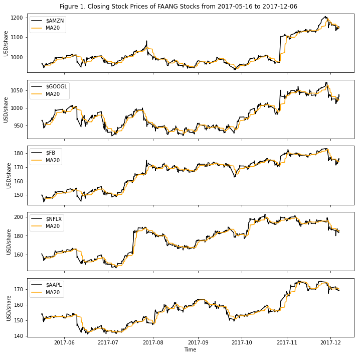

```python
%%local
start = googl.dateTime.iloc[0]
end = googl.dateTime.iloc[-1]
fig, axes = plt.subplots(5, 1, figsize=(10, 2*5), sharex=True)

for ax, stock, label in zip(axes, [amzn, googl, fb, nflx, aapl],
                            ['AMZN', 'GOOGL', 'FB', 'NFLX', 'AAPL']):

    ax.plot(stock.dateTime, stock.Close, color='black', label=f'${label}')
    ax.plot(stock.dateTime,
            stock.Close.rolling(window=20).mean(),
            color='orange',
            label='MA20')
    ax.set_ylabel('USD/share')
    ax.legend(loc='upper left')
ax.set_xlabel('Time')
plt.suptitle(f'Figure 1. Closing Stock Prices of FAANG'
             f' Stocks from {start.date()} to {end.date()}')
plt.tight_layout();
```

```python
%%local
for stock, label in zip([fb, amzn, googl, aapl, nflx],
                        ['FB', 'AMZN', 'GOOGL', 'AAPL', 'NFLX']):
    growth = ((stock.Close.iloc[-1] - stock.Close.iloc[0])/
              stock.Close.iloc[0])
    print(f'Growth Over the Observed Period for ${label}: '
          f'{growth*100:0.2f}%')
```

```
Growth Over the Observed Period for $FB: 17.54%
Growth Over the Observed Period for $AMZN: 19.52%
Growth Over the Observed Period for $GOOGL: 7.18%
Growth Over the Observed Period for $AAPL: 9.55%
Growth Over the Observed Period for $NFLX: 15.26%
```

From a 6 to 12-month term investment, putting money in AMZN seems to be the best option since it has a growth rate of 19.52% over the time period compared to AAPL and GOOGL whose growth is at a measly <10%. FB (17.54%) and NFLX (15.26%) also seems to be a good investment with AMZN., with a long term strategy AMZN Stocks is the best option.

**Correlations among Tech Stocks**

Aside from overall growth in the observed time period, we can also look at the correlations among the stock prices. We know that industry-related articles affect not just one company. Since we are looking at technology companies -- the biggest ones also! -- we speculate that there is some form of correlation among their stock prices. In the next two visualizations, we look at the correlations of the stock with respect to each other.

```
Figure 2. Pair plot of Stocks
```

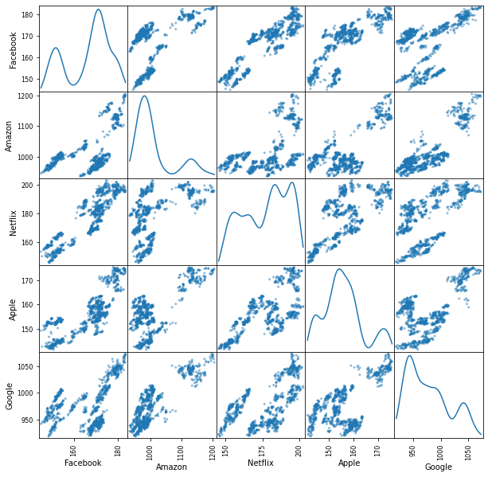

```python
%%local
from pandas.plotting import scatter_matrix
df = pd.DataFrame({'Facebook': fb.Close,  'Amazon': amzn.Close,
                 'Netflix': nflx.Close, 'Apple': aapl.Close,
                 'Google': googl.Close})
fig, ax = plt.subplots(1, 1, figsize=(10, 10))
scatter_matrix(df, ax=ax, diagonal='kde')
print('Figure 2. Pair plot of Stocks');
```

Across the board, there seems to be a generally positive correlation among all stock prices, i.e. if one increase, all of them increases. This is expected because the natural tendency of stocks is to grow over a time period. In order to appreciate the pairplot better, we needed to look at the pearson correlation coefficients and plot them as a heatmap (Note: we are using barebones matplotlib to illustrate this since we are having trouble using seaborn in the PySpark kernel).

```
Pearson Correlation of Stocks:
           Facebook  Amazon  Netflix  Apple  Google
Facebook      1.00    0.55     0.90   0.81    0.46
Amazon        0.55    1.00     0.53   0.72    0.86
Netflix       0.90    0.53     1.00   0.70    0.59
Apple         0.81    0.72     0.70   1.00    0.63
Google        0.46    0.86     0.59   0.63    1.00
```

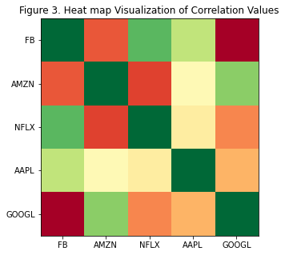

```python
%%local
print('Pearson Correlation of Stocks:\n',
     df.corr().round(2))

fig, ax = plt.subplots(1, 1, figsize=(5,5))
ax.imshow(df.corr().round(2), cmap='RdYlGn', interpolation='nearest')
ax.set_title('Figure 3. Heat map Visualization of Correlation Values')
ax.set_xticklabels(['FB', 'FB', 'AMZN', 'NFLX', 'AAPL', 'GOOGL'])
ax.set_yticklabels(['FB', 'FB', 'AMZN', 'NFLX', 'AAPL', 'GOOGL']);
```

From the heatmap above, we can say that (Facebook, Netflix), (Facebook, Apple), and (Amazon, Google) are highly correlated while (Facebook, Google), (Amazon, Facebook), and (Amazon, Netflix) and least correlated. We would like to note that the visuals we generated are for appreciation purposes only as an indepth hypothesis testing is needed to validate the correlations.

#### **Autocorrelations of Closing Stock Price**

The stock price plots in Figure 1 shows observable seasonality, noise, and trends. These artefacts make the trends not stationary and difficult to model. In order to make our data stationary, we subtracted a lag of the time series to itself and use that as a target variable -- the stock return column! The differenced series does not exhibit any seasonality and autocorrelations.

We use the time differenced version to allow the model to learn the true variations/ noise in the series. We can correct for the time lag by doing the inverse of the differencing function.

Recall that the Stock Return `Return` is given by:

\begin{align*} R_t &= \frac{S_t - S_{t-1}}{S_{t-1}} \end{align*}

We can compute for the Closing Price by computing for $S_t$

\begin{align*} S_t &= (R_t+1)\;S_{t-1} \end{align*}

The next set of visuals shows us the Autocorrelation plots per each Stock Price side-by-side with its Stock Return (differenced series).

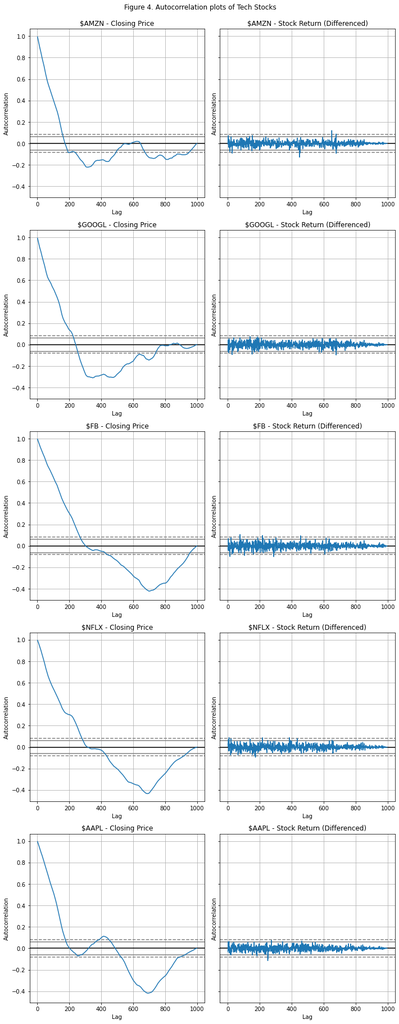

```python
%%local
from pandas.plotting import autocorrelation_plot

fig, axes = plt.subplots(5, 2, figsize=(5*2, 5*5),
                         sharey=True)

for ax, stock, label in zip(axes, [amzn, googl, fb, nflx, aapl],
                            ['AMZN', 'GOOGL', 'FB', 'NFLX', 'AAPL']):

    autocorrelation_plot(stock.Close, ax=ax[0])
    autocorrelation_plot(stock.Return.dropna(), ax=ax[1])
    ax[0].set_title(f'${label} - Closing Price')
    ax[1].set_title(f'${label} - Stock Return (Differenced)')

plt.tight_layout();
plt.suptitle('Figure 4. Autocorrelation plots of Tech Stocks', y=1.01);
```

#### Description of Sentiment Scores and Feature Correlations

In this section we look at the correlation of all the feature variables that we will use in the Machine Learning Algorithm. The correlation plots show that (`TONE`, `POSITIVE_SCORE`), (`TONE`, `NEGATIVE_SCORE`) and (`Close`, `prevClose`) are highly correlated. This is expected given that `TONE` is obtained as the difference between `POSITIVE_SCORE` and `NEGATIVE_SCORE`, while `prevClose` is just a lag `Close`. Figure 5a (top) shows the correlation for AMZN stock. The correlation plots for other tech stocks are shown in Figure 5b (below).

Interestingly, `prevReturn` and `Return` are not correlated with each other despite being lag copies of one another. Since none of the features are strongly correlated with the Target variable (`Return`) we will keep one of the correlated pairs identified to save memory.

```
Figure 5a. Correlation Plot for AMZN
```

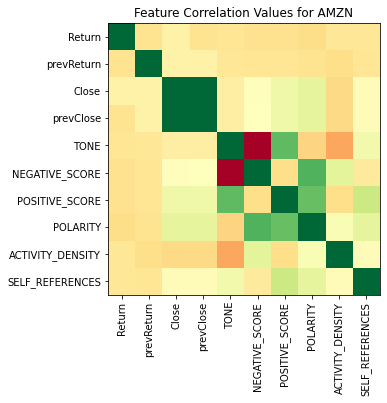

```python
%%local

def plot_correlation(df, label='stock', ax=None):
    """Plot correlation heat map of `df` using `ax`"""
    features = df.columns.drop('dateTime').tolist()
    corr = df.drop(['dateTime'], axis=1).corr().round(2)
    if ax == None:
        fig, ax = plt.subplots(1, 1, figsize=(5,5))

    ax.imshow(corr, cmap='RdYlGn', interpolation='nearest')
    ax.set_title(f'Feature Correlation Values for {label}')
    ax.set_xticks(range(0, len(features)))
    ax.set_yticks(range(0, len(features)))
    ax.set_xticklabels(features, rotation=90)
    ax.set_yticklabels(features, rotation=0)

    return ax

fig, ax = plt.subplots(1, 1, figsize=(5, 5))

plot_correlation(amzn_joined, label='AMZN', ax=ax)
print('Figure 5a. Correlation Plot for AMZN');
```

```
Figure 5b. Correlation Plot for FB, GOOGL, AAPL, NFLX
```

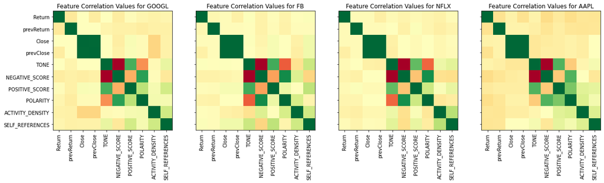

```python
%%local
fig, axes = plt.subplots(1, 4, figsize=(20, 5),
                         sharey=True, sharex=True)

for ax, stock, label in zip(axes.flatten(),
                    [googl_joined, fb_joined,
                     nflx_joined, aapl_joined],
                    ['GOOGL', 'FB', 'NFLX', 'AAPL']):
    plot_correlation(stock, label=label, ax=ax)
print('Figure 5b. Correlation Plot for FB, GOOGL, AAPL, NFLX')
```

Considering the results of the feature correlation analysis, we limit our features to the following columns: `prevReturn`, `POLARITY`, `TONE`, `ACTIVITY_DENSITY`, `SELF_REFERENCES`, `prevClose`.

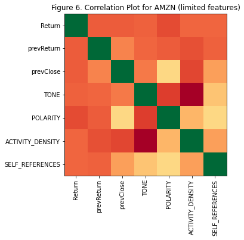

```python
%%local
drop = ['POSITIVE_SCORE', 'NEGATIVE_SCORE', 'Close']

ax = plot_correlation(amzn_joined.drop(drop, 1), label='AMZN')
ax.set_title('Figure 6. Correlation Plot for AMZN (limited features)')
plt.show()
```

Note that the correlation plot above reflect relative values within the matrix. We can be assured that the there are no strongly correlated variables in the mix by inspecting the pairplot of the dataframe. See Figure 7.

```
Figure 7. Pair plot of AMZN showing the absence of highly correlated variables
```

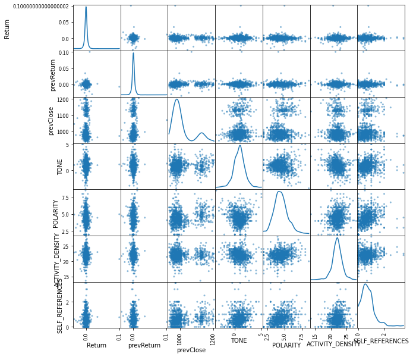

```python
%%local
from pandas.plotting import scatter_matrix

fig, ax = plt.subplots(1, 1, figsize=(10, 10))
scatter_matrix(amzn_joined.drop(drop+['dateTime'], 1),
               ax=ax,
               diagonal='kde')
print('Figure 7. Pair plot of AMZN showing the absence '
      'of highly correlated variables');
```

We now use the learnings from the EDA to shape the Machine Learning models in the succedding section.

### Prediction of Stock Returns (and Closing Price) using `GBTRegression` Model

For the prediction, we implemented a Gradient Boosted Tree Regression (`pyspark.ml.regression.GBTRegression`) on the selected features from the Exploratory Data Analysis: `TONE`, `POLARITY`', `ACTIVITY_DENSITY`, `prevClose`, `SELF_REFERENCES`, and `prevReturn`. We used the stock `Return` as the target variable. We decided to include `prevReturn` as a feature because our analysis show that it is not correlated to the target variable.

**Defining Train-Test Split**

We define an 80-20 train-test split for the implementation. To be consistent, we spliced the time series at 31 October 2017 and used series data from 1 November 2017 to 6 December 2017 as test data. We stored the train and test sets in a dictionary to improve code readability and to make data calls faster, simpler, and more intuitive.

```python
def split_train_test(sdf,
                     test_split='2017-10-31 23:59:59',
                     start='2017-05-01 00:00:00',
                     end='2017-12-31 23:59:59',
                     stock_code='stock'):
    """Slice the time series based on `test_split`.
    Returns train and test split of `sdf`."""

    train = sdf.filter(col('dateTime').between(start, test_split))
    test = sdf.filter(col('dateTime').between(test_split, end))
    print(f'Size of (Train, Test) Sets for ${stock_code.upper()}: ',
                 (train.distinct().count(),
                  test.distinct().count()))

    return train, test

# We store the results in a dictionary for ease in calling the data
FAANG  = {}
stocks = [fb_joined, amzn_joined, aapl_joined, nflx_joined, googl_joined]
stocklabels = ['fb', 'amzn', 'aapl', 'nflx', 'googl']
for stock, stocklabel in zip(stocks, stocklabels):

    train, test = split_train_test(stock,  stock_code=stocklabel)
    FAANG.update({stocklabel.upper() : {'train' : train,
                                        'test': test}
                 })
```

```
Size of (Train, Test) Sets for $FB:  (820, 169)
Size of (Train, Test) Sets for $AMZN:  (800, 167)
Size of (Train, Test) Sets for $AAPL:  (814, 170)
Size of (Train, Test) Sets for $NFLX:  (817, 170)
Size of (Train, Test) Sets for $GOOGL:  (820, 170)
```

**Model Training and Evaluation**

We chose a Gradient Boosted Tree (GBT) Regression as the model to combine the benefits of ensemble training (use of multiple trees/ estimators), and the power of gradient boosting in improving the performance of weak learners. We set `maxDepth = 5` since GBTs easily overfit at high depth.

```python
from pyspark.ml.evaluation import RegressionEvaluator
from pyspark.ml import Pipeline
from pyspark.ml.regression import GBTRegressor
from pyspark.ml.feature import VectorAssembler
from pyspark.ml.feature import StandardScaler

def compute_predictClose(sdf):
    """Compute the predicted `Close` price based on
    predicted Returns as a new column in the `sdf`"""
    return (sdf.orderBy('dateTime')
              .withColumn('predictClose',
                          col('prevClose') * (1+ col('prediction'))))


def train_model(train, test, Model=None, target='Return',
                Scaler=StandardScaler, stock_label='Stock' ):
    """Trains a regressor `Model` (default GBTRegressor) with `target` as
    y values. Returns the `train` and `test` spark DataFrames with
    a prediction column."""

    feature_columns = ['TONE', 'POLARITY', 'ACTIVITY_DENSITY',
                       'prevClose', 'SELF_REFERENCES', 'prevReturn']
    if Model == None:
        Model = GBTRegressor(featuresCol='features_scaled',
                         labelCol=target,
                         maxDepth=5,
                         maxIter=100)

    pipe = Pipeline(stages=[
        VectorAssembler(inputCols=feature_columns, outputCol='features'),
        Scaler(inputCol='features', outputCol='features_scaled'),
        Model
            ])

    model_trained = pipe.fit(train)
    test_predict = model_trained.transform(test)
    train_predict = model_trained.transform(train)

    evaluator = RegressionEvaluator(labelCol=target)
    print(f'Evaluating trained model results for {stock_label}:')
    print('\tTrain mse: ', evaluator.evaluate(train_predict,
                                            {evaluator.metricName: 'mse'}))
    print('\tTest mse: ', evaluator.evaluate(test_predict,
                                           {evaluator.metricName: 'mse'}))

    return (compute_predictClose(train_predict),
            compute_predictClose(test_predict),
            pipe)
```

Storing the results the FAANG dictionary defined in the previous section.

```python
for stock in FAANG.keys():

    train, test, pipe = train_model(FAANG[stock]['train'],
                                    FAANG[stock]['test'],
                                    stock_label=stock)
    FAANG[stock].update({'trainResults' : train,
                        'testResults' : test,
                        'pipeResults' : pipe})
```

```
Evaluating trained model results for FB:
	Train mse:  5.368935018980445e-07
	Test mse:  3.487748289205638e-05
Evaluating trained model results for AMZN:
	Train mse:  5.633212847854079e-07
	Test mse:  5.8898186527444e-05
Evaluating trained model results for AAPL:
	Train mse:  6.745560883856134e-07
	Test mse:  2.3416410028335806e-05
Evaluating trained model results for NFLX:
	Train mse:  1.7833621209309781e-06
	Test mse:  6.838373556242183e-05
Evaluating trained model results for GOOGL:
	Train mse:  5.447108501222496e-07
	Test mse:  1.9471889463768556e-05
```

**Use of Mean Squared Error as Loss Function**

Since the mean of Stock Returns is zero we can expect that it can be *naively* approximated by a horizontal line. That said, using $R^2$ as an accuracy measure will yield negative values, if not zero values. To account for estimation errors, we decided to use Mean Squared Error. The metric penalizes huge errors than small errors allowing us the model to learn spikes in the Return plot.

## **Discussion of Results**

Like in previous sections, we store the Spark dataframes locally to plot them using our usual visualization tools.

**Preparing Visualization Tools**

```python
fb_train, fb_test = FAANG['FB']['trainResults'], FAANG['FB']['testResults']
nflx_train, nflx_test = (FAANG['NFLX']['trainResults'],
                         FAANG['NFLX']['testResults'])
googl_train, googl_test = (FAANG['GOOGL']['trainResults'],
                           FAANG['GOOGL']['testResults'])
amzn_train, amzn_test = (FAANG['AMZN']['trainResults'],
                         FAANG['AMZN']['testResults'])
aapl_train, aapl_test = (FAANG['AAPL']['trainResults'],
                         FAANG['AAPL']['testResults'])
```

```python
%spark -o fb_train
```

```python
%spark -o fb_test
```

```python
%spark -o nflx_train
```

```python
%spark -o nflx_test
```

```python
%spark -o googl_train
```

```python
%spark -o googl_test
```

```python
%spark -o amzn_train
```

```python
%spark -o amzn_test
```

```python
%spark -o aapl_train
```

```python
%spark -o aapl_test
```

```python
%%local

def plot_results(train, test, stock_label='stock'):
    """Plot results given a stock train and test dataframes"""

    def generate_figure():
        """Return axes for plotting"""
        fig = plt.figure(constrained_layout=True, figsize=(3.5*2, 3.5*3))
        gs = fig.add_gridspec(3, 2)
        ax = fig.add_subplot(gs[0, :])
        (bx1, bx2) = fig.add_subplot(gs[1, 0]), fig.add_subplot(gs[1, 1])
        (cx1, cx2) = fig.add_subplot(gs[2, 0]), fig.add_subplot(gs[2, 1])
        return fig, [ax, bx1, bx2, cx1, cx2]

    fig, axes = generate_figure()
    start = 0
    train_end = len(train)
    end = train_end + len(test)
    time_range = (train.dateTime.dt.date.tolist()+
                  test.dateTime.dt.date.tolist())

    # Plot Full Time Range
    new_axes = []
    axes[0].plot(train.dateTime.dt.date, train.Close,
                 color='gray', label='actual')
    axes[0].plot(test.dateTime.dt.date, test.Close, color='black')
    axes[0].plot(test.dateTime.dt.date, test.predictClose, '--y')
    axes[0].set_title(f'Prediction Comparison for {stock_label}')
    axes[0].set_ylabel('Share price (USD/ share)')
    axes[0].set_xlabel('Time')
    axes[0].legend(loc='upper left')

    new_axes.append(axes[0])
    for bx, actual, predict, label in zip(axes[1:3],
                                          [train.Close, test.Close],
                                          [train.predictClose,
                                          test.predictClose],
                                          ['train', 'test']):
        bx.plot(actual, color='black', label='actual')
        bx.plot(predict, '--y', label='predict')
        bx.set_title(f'{label.title()} set results (Close Price)')
        bx.set_ylabel('Share price (USD/ share)')
        bx.set_xlabel('Timestep')
        bx.legend(loc='upper left')
        new_axes.append(bx)


    for cx, actual, predict, label in zip(axes[3:5],
                                          [train.Return, test.Return],
                                          [train.prediction,
                                          test.prediction],
                                          ['train', 'test']):
        cx.plot(actual, color='black', label='actual')
        cx.plot(predict, '--y', label='predict')
        cx.set_title(f'{label.title()} set results (Stock Returns)')
        cx.set_ylabel('Stock Return')
        cx.set_xlabel('Timestep')
        cx.legend(loc='upper left')
        new_axes.append(cx)

    return new_axes
```

### General Observations

Overall, all predictions was able to capture the behavior of the stock with minimal (and forgivable) over estimations. Surprisingly, the model was able to fit the training set well -- a sign of overfitting. Gradient Boosted Trees loves to overfit to the training data in hopes of generalizing well in the test set.

Some models were able to capture (and predict) spikes and trends in the Stock Return test set and that shows how well the estimator is. However, it can also be argued that the results of the model is an artefact of the use of intraday price movements, which are more granullar (and easier to trace) than daily price movements.

We decided to not conduct a hyper parameter tuning step because we are satisfied with the MSE computed by the Regression Evaluator. Furthermore, it was able to provide a satisfying test set prediction results.

**Prediction Results for FB**

For Facebook, the model was not able to capture two major dips in the Return Test set -- it predicted it several time steps in advance. However, translating it to Closing prices, it seems to approximate the trend well, sans the two dips mentioned earlier. In hindsight, the preempted dips could have served as a warning from any trader that a huge drop will happen in the future.

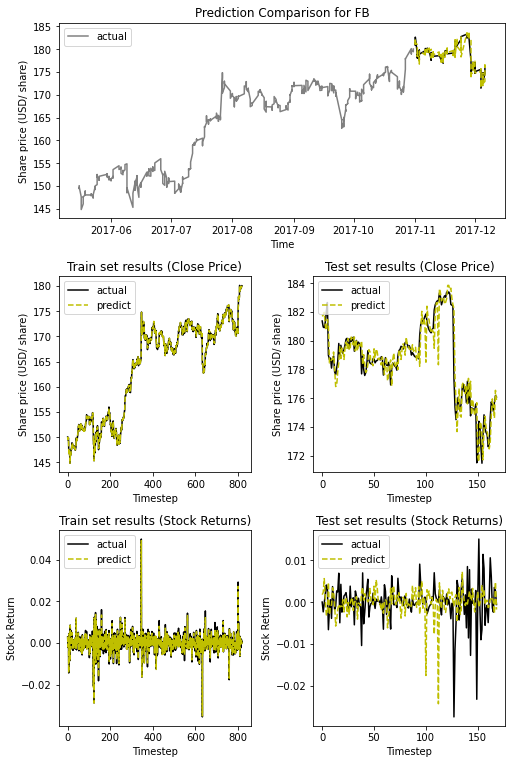

```python
%%local
fb_axes = plot_results(fb_train, fb_test, stock_label='FB')
```

**Prediction Results for NFLX**

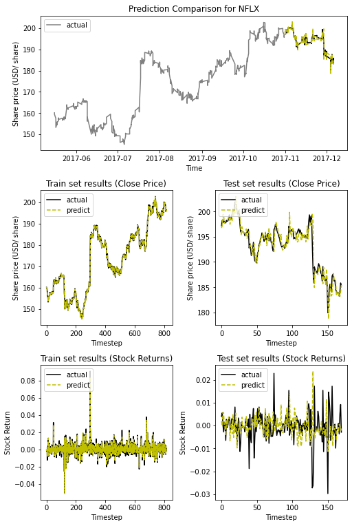

```python
%%local
nflx_axes = plot_results(nflx_train, nflx_test, stock_label='NFLX')
```

**Prediction Results for GOOGL**

Results for GOOGL is looks promising from a Close Price perspective. While it did not identify all peaks and spikes in the Test Stock returns, the overall direction of "spikes" was predicted i.e. there were no opposite/ behavior observed that may cause a huge deviation from actual values.

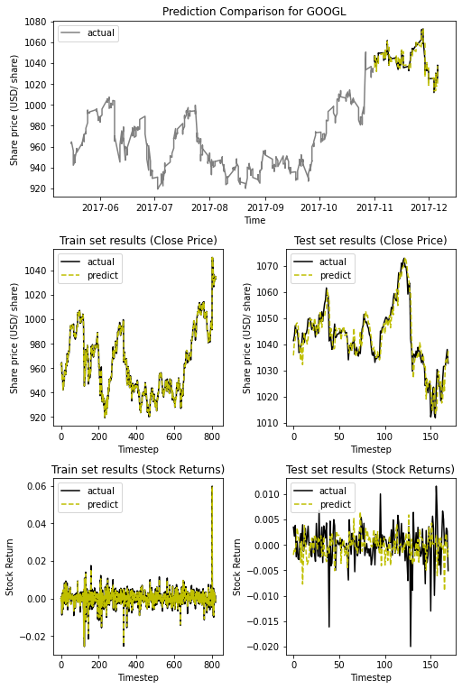

```python
%%local
googl_axes = plot_results(googl_train, googl_test, stock_label='GOOGL')
```

**Prediction Results for AMZN**

Returns predictions for AMZN was a bit erratic but translating it to Closing price provided reliable results with somewhat good approximations of peaks and valleys

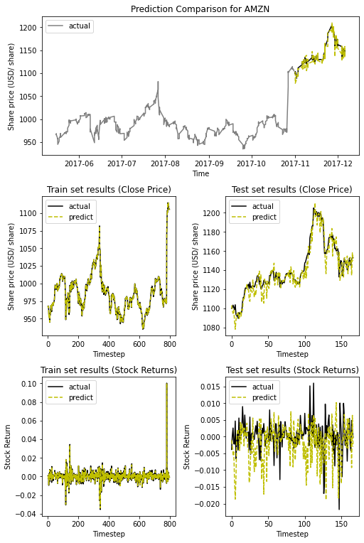

```python
%%local
amzn_axes = plot_results(amzn_train, amzn_test, stock_label='AMZN')
```

**Prediction Results for AAPL**

AAPL predictions was able to capture medium sizes spikes but not the largest dips in the Return Test set. However, it seems to provide a good estimation of the actual model with slight off predictions.

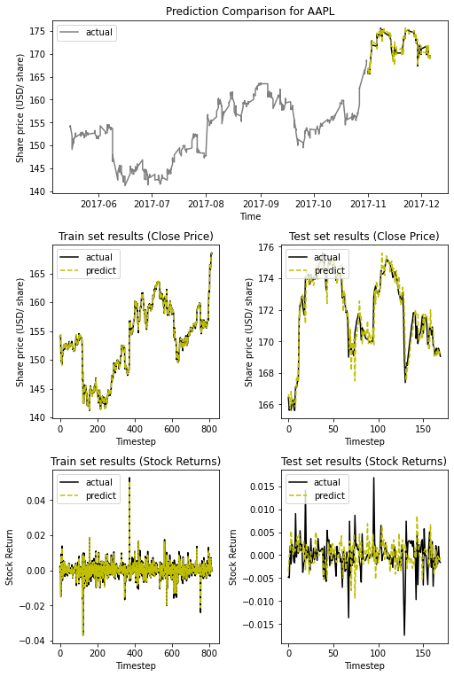

```python
%%local
aapl_axes = plot_results(aapl_train, aapl_test, stock_label='AAPL')
```

## Conclusions and Recommendations

In this paper, we managed to demostrate how the sentiments scores in the Global Knowledge Graph (GKG) can be used as stock market price indicators with features extracted from the time series with satisfying results. However, we also observed that models were not able to accurately predict the test set and were only able to model price direction. As such, we recommend the use of other machine learning models (regressors and classifiers), and the use of deep learning models such as LSTM and Bi-LSTM to enhance the results. Further, we recommend to use daily price stock movements over a larger time span (preferably, 2 years) to assess the viability of the methodology since we hypothesize that granularity of available data (per hour) may have made it easier for the model to trace the path and predict the future values.

## References

Corporate Finance Institute (n.d.) What is the New York Stock Exchange. https://corporatefinanceinstitute.com/resources/knowledge/trading-investing/new-york-stock-exchange-nyse/#:~:text=The%20New%20York%20Stock%20Exchange%20(NYSE)%20is%20the%20largest%20securities,stocks%20and%20securities%20a%20day.

Divine, J. (2020). 2020 The Year Tech Took Over. US News Money. https://money.usnews.com/investing/stock-market-news/articles/tech-stocks-is-2020-the-year-software-eats-the-world

Investopedia (2020). The NYSE and NASBAQ: How They Work. Investopedia.com. https://www.investopedia.com/articles/basics/03/103103.asp#:~:text=The%20Nasdaq%20is%20known%20for,more%20stable%20and%20well%2Destablished.

Kharysh, O. (2019). Stock Return Predictability Based on World News Sentiment [Bachelor's Thesis]. Ukrainian Catholic University.

TradingHours.com (2020). List of Stock Markets. https://www.tradinghours.com/markets

World Federation of Exchanges. (17 August 2014) "Monthly Reports". World-Exchanges.org.

## Appendix

### Screenshots of Instances

[figure not shown]

### Size of Raw Data Processed

Since the data is available in Jojie, we use the following command to estimate the file size of the data processed

```python
!du -ch /mnt/data/public/gdeltv2/gkg/20170[56789]??1[6789]* | tail -1
```

```
26G	total
```

```python
!du -ch /mnt/data/public/gdeltv2/gkg/20170[56789]??2[012]* | tail -1
```

```
18G	total
```

```python
!du -ch /mnt/data/public/gdeltv2/gkg/20171[012]??1[6789]* | tail -1
```

```
16G	total
```

```python
!du -ch /mnt/data/public/gdeltv2/gkg/20171[012]??2[012]* | tail -1
```

```
12G	total
```

The combined raw data processed by the paper is **72GB.**

### Packages installed in the Spark Cluster

```python
sc.list_packages()
```

[output not shown]

[output cut: 20 more lines]

[output not shown]